# Practical Machine Learning

PW

30 July 2017

## Executive Summary

The aim of this project is to use the Weight Lifting Exercise dataset and build a prediction model on the various techniques to perform barbell lifts measured by accelerometers. Find out more details of the dataset and description [here](http://groupware.les.inf.puc-rio.br/har) (Weight Lifting Exercise Dataset section).

### Data Processing and Analysis

#### About the Dataset

The dataset consist of 6 participants wearing accelerometers on the belt, forearm, arm and the dumbell. The participants were asked to perform one set of 10 repetitions of biceps curl in five different methods:  
1. Class A: Exactly according to the specification  
2. Class B: Throwing the elbows to the front  
3. Class C: Lifting the dumbell only halfway  
4. Class D: Lowering the dumbell only halfway  
5. Class E: Throwing the hips to the front

Find out more of the project description [here](http://groupware.les.inf.puc-rio.br/har#ixzz3RDCCaU6P)

```r
# load all required libraries
library(data.table)
library(caret)
library(randomForest)
library(foreach)
library(rpart)
library(rpart.plot)
library(corrplot)
library(rattle)
library(plyr)
library(ipred)
library(e1071)

# load train & test dataset
train <- read.csv("~/Downloads/pml-training.csv", na.strings=c("#DIV/0!"," ", "", "NA", "NAs", "NULL"))
test <- read.csv("~/Downloads/pml-testing.csv", na.strings=c("#DIV/0!"," ", "", "NA", "NAs", "NULL"))

dim(train)
```

```
## [1] 19622   160
```

```r
dim(test)
```

```
## [1]  20 160
```

```r
# clean the dataset
trainClean <- train[, -which(names(train) %in% c("X", "user_name", "raw_timestamp_part_1", "raw_timestamp_part_2", "cvtd_timestamp", "new_window", "num_window"))]

# remove columns with NAs where imputing is not an option
trainClean = trainClean[, colSums(is.na(trainClean)) == 0]

# remove variables with 0 or near to 0 variance
zero_variance =nearZeroVar(trainClean[sapply(trainClean, is.numeric)], saveMetrics=TRUE)
trainClean = trainClean[, zero_variance[, 'nzv'] == 0]

correlation_matrix <- cor(na.omit(trainClean[sapply(trainClean, is.numeric)]))

dim(correlation_matrix)
```

```
## [1] 52 52
```

```r
correlationmatrixdegreesoffreedom <- expand.grid(row = 1:52, col = 1:52)
# return correlation matrix in matrix format
correlationmatrixdegreesoffreedom$correlation <- as.vector(correlation_matrix)
removehighcorrelation <- findCorrelation(correlation_matrix, cutoff = .7, verbose = TRUE)
# this removes highly correlated variables (in psychometric theory .7+ correlation is a high correlation)
trainClean <- trainClean[, -removehighcorrelation]

for(i in c(8:ncol(trainClean)-1)) {
    trainClean[,i] = as.numeric(as.character(trainClean[,i]))}

for(i in c(8:ncol(test)-1)) {
    test[,i] = as.numeric(as.character(test[,i]))}

# clean dataset will only consist of complete columns
# for cleaner dataset, user name, timestamps & windows will be removed with blank columns
features <- colnames(trainClean[colSums(is.na(trainClean)) == 0])[-(1:7)]
modelling <- trainClean[features]

# final clean dataset ready for modelling
features

# for cross-validation, split the sample in two to divide training and testing
iid <- createDataPartition(modelling$classe, p=0.6, list=FALSE )
training <- modelling[iid,]
testing <- modelling[-iid,]
```

[output not shown]

### Classification Model

In this section, our plan is to build classification tree, random forest, boosting model and bagging for activity classification and then choose the one with the best the out-of-sample accuracy.

#### Classification Tree

In the first test, we use a regression tree with the method `rpart`.

[figure not shown]

```r
library(rattle)
library(rpart.plot)
library(rpart)

# regression tree model
set.seed(123)
modTree <- train(classe ~ .,data=training, method="rpart")
save(modTree,file="modTree.RData")

load("modTree.RData")
fancyRpartPlot(modTree$finalModel)
```

```r
# out-of-sample errors of regression tree model using validation dataset
predTree <- predict(modTree, testing)
cm1 <- confusionMatrix(predTree, testing$classe)
cm1$table
```

```
##           Reference
## Prediction    A    B    C    D    E
##          A 1570  326  170  106  132
##          B   72  333   41   65  263
##          C  281  304  776  217  320
##          D  299  312  367  863  396
##          E   10  243   14   35  331
```

#### Random Forest

We will use the random forest model here using three fold cross validation in our model here due to computational cost factor.

```r
set.seed(123)

# random forest model
system.time(modForest <- train(classe ~ ., method = "rf",
                data = training, importance = TRUE,
                trControl = trainControl(method = "cv", number = 3)))
```

```
##    user  system elapsed
## 300.934   3.667 308.250
```

```r
save(modForest,file="modForest.RData")

load("modForest.RData")
variable <- varImp(modForest)
variable$importance[1:10,]
```

```
##                             A        B        C        D        E
## yaw_arm              43.32410 76.43762 58.81903 69.97418 86.71900
## total_accel_arm       0.00000 25.17893 23.84208 30.06173 33.75655
## gyros_arm_y          39.84029 84.49825 63.85277 61.13837 69.15205
## gyros_arm_z          18.40968 35.83019 21.29428 19.87247 27.83160
## magnet_arm_x         20.66630 35.25766 42.13136 48.57352 34.68961
## magnet_arm_z         40.08508 57.55172 50.33823 50.65125 56.93843
## roll_dumbbell        40.14859 53.22367 90.01431 59.11751 63.32507
## pitch_dumbbell        9.71540 44.55315 37.51898 24.12634 35.02686
## yaw_dumbbell         21.66293 46.05646 55.66035 54.49861 60.35973
## total_accel_dumbbell 45.76205 67.76901 57.95194 59.81701 70.36915
```

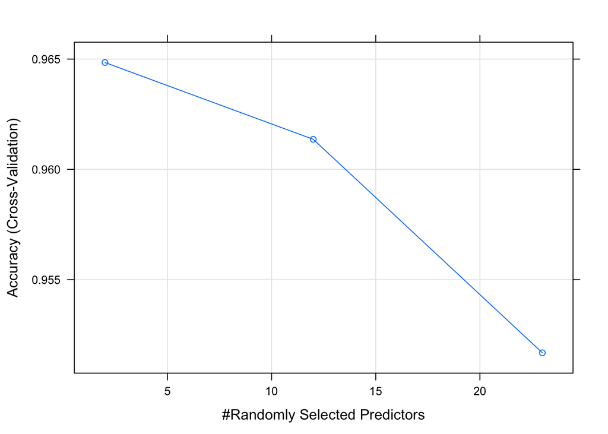

```r
# out-of-sample errors of random forest model using validation dataset
predForest <- predict(modForest, testing)
cm2 <- confusionMatrix(predForest, testing$classe)

# summary of final model
plot(modForest)
```

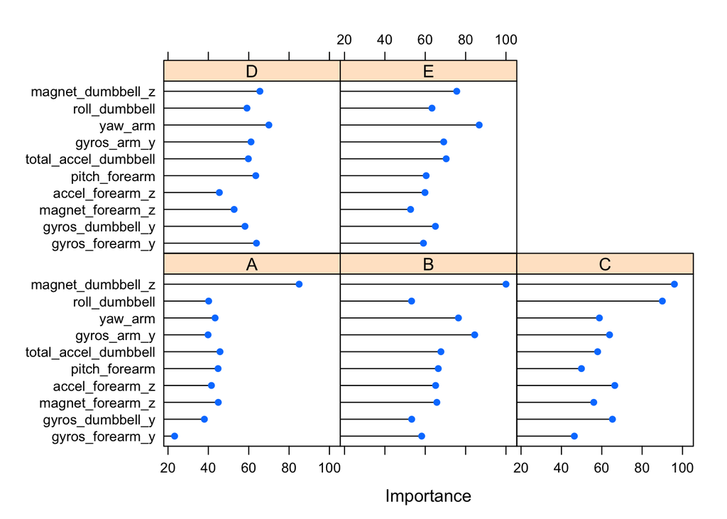

```r
plot(varImp(modForest), top = 10)
```

A list of top ten important variables in the model is shown above in relation to each class of activity.

#### Boosting

For boosting tree model, we will first use three fold cross-validation.

```r
# simple boost tree fitting model
set.seed(2)
system.time(modBoost <- train(classe ~ .,
                   method = "gbm",
                   data = training,
                   verbose = FALSE,
                   trControl = trainControl(method = "cv", number = 3)))
```

```
##    user  system elapsed
##  52.457   0.799  53.980
```

```r
save(modBoost,file="modBoost.RData")

load("modBoost.RData")

# out-of-sample errors using validation dataset
predBoost <- predict(modBoost, testing)
cm3 <- confusionMatrix(predBoost, testing$classe)
cm3$overall
```

```
##       Accuracy          Kappa  AccuracyLower  AccuracyUpper   AccuracyNull
##   8.555952e-01   8.171867e-01   8.476218e-01   8.633035e-01   2.844762e-01
## AccuracyPValue  McnemarPValue
##   0.000000e+00   6.353777e-48
```

With our dataset, we will generate a grid of 15 combinations and use tuneGrid argument to the training function to use these values as we can also tune over the number of trees and complexity of the tree.

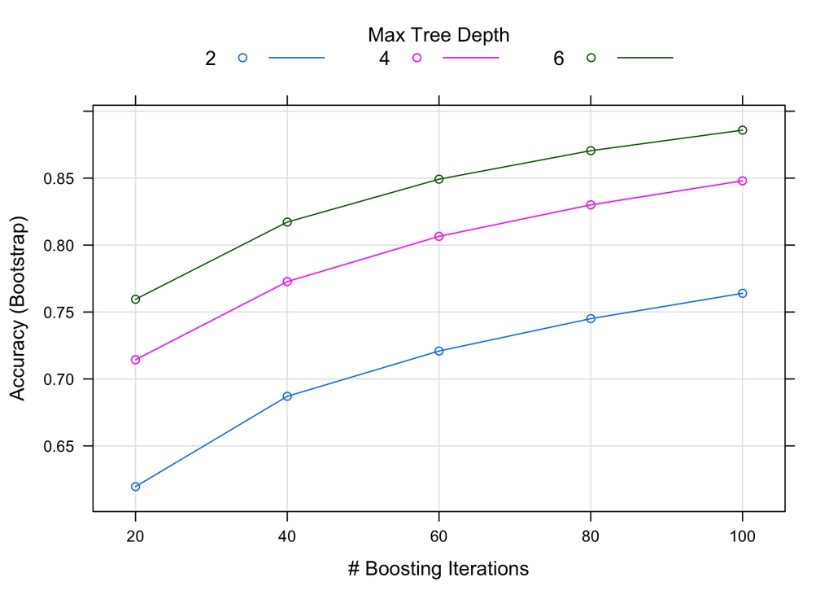

```r
## model tuning
gbmGrid <- expand.grid(.interaction.depth=(1:3)*2, .n.trees=(1:5)*20, .shrinkage=.1,
                       .n.minobsinnode = c(10))
bootControl <- trainControl(number=50)
set.seed(2)
gmbFit<- train(classe ~ .,
                method = "gbm",
                data = training,
                verbose = F,
                trControl = bootControl,
                bag.fraction=0.5,
                tuneGrid=gbmGrid)
save(gmbFit,file="gmbFit.RData")

load("gmbFit.RData")
plot(gmbFit)
```

```r
# out-of-sample errors using validation dataset
predGMB <- predict(gmbFit, testing)
cmGMB <- confusionMatrix(predGMB, testing$classe)
cmGMB$overall
```

```
##       Accuracy          Kappa  AccuracyLower  AccuracyUpper   AccuracyNull
##   8.968901e-01   8.694543e-01   8.899494e-01   9.035344e-01   2.844762e-01
## AccuracyPValue  McnemarPValue
##   0.000000e+00   4.487499e-39
```

#### Bagging

```r
system.time({modBag <- train(classe ~ .,data=training,method="treebag")})
```

```
##    user  system elapsed
## 158.108   6.649 165.601
```

```r
save(modBag,file="modBag.RData")

load("modBag.RData")
predBag <- predict(modBag, testing)
cm4 <- confusionMatrix(predBag, testing$classe)
varImp(modBag)
```

```
## treebag variable importance
##
##   only 20 most important variables shown (out of 23)
##
##                      Overall
## magnet_dumbbell_z     100.00
## roll_forearm           94.47
## roll_dumbbell          92.43
## pitch_forearm          87.53
## yaw_arm                79.63
## gyros_dumbbell_y       61.23
## yaw_dumbbell           51.01
## magnet_arm_x           48.73
## total_accel_dumbbell   47.72
## accel_forearm_x        42.96
## magnet_forearm_z       40.11
## pitch_dumbbell         39.63
## accel_forearm_z        38.50
## gyros_arm_y            35.66
## magnet_arm_z           29.80
## magnet_forearm_y       29.32
## yaw_forearm            29.08
## magnet_forearm_x       21.63
## total_accel_arm        19.38
## gyros_forearm_y        11.99
```

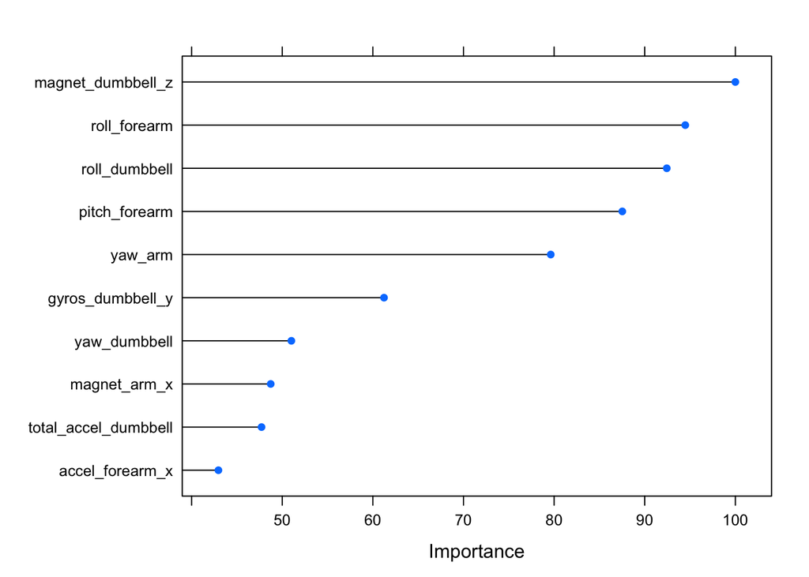

```r
plot(varImp(modBag), top = 10)
```

#### Prediction Model Selection

After running all the prediction models, they are summarized in the table below:

```r
summa <- data.frame(Tree=cm1$overall[1],
                    rf=cm2$overall[1],
                    boosting=cm3$overall[1],
                    bagging=cm4$overall[1])
summa
```

```
##               Tree        rf  boosting  bagging
## Accuracy 0.4936273 0.9742544 0.8555952 0.957558
```

We can see that the random forest model had produced the highest level of accuracy as compared to the other prediction models. Therefore, we will be selecting the random forest model as the model of choice for our prediction on the testing dataset.

### Prediction and Results

```r
testing$classe <- as.character(predict(modForest, testing))

modForest$finalModel
```

```
##
## Call:
##  randomForest(x = x, y = y, mtry = param$mtry, importance = TRUE)
##                Type of random forest: classification
##                      Number of trees: 500
## No. of variables tried at each split: 2
##
##         OOB estimate of  error rate: 2.38%
## Confusion matrix:
##      A    B    C    D    E class.error
## A 3336    6    1    4    1 0.003584229
## B   54 2198   19    4    4 0.035541904
## C    2   38 1999   13    2 0.026777020
## D    0    0   70 1852    8 0.040414508
## E    1   17    6   30 2111 0.024942263
```

### Conclusion

For this project, we used four types of prediction models to build an accurate prediction model on the “classe” variable of the dataset. The results above had shown that the random forest model produced the highest level of accuracy among the other models during cross validation.

One suggestion to improve the results of our model performance is to finetune to model’s parameters and further explore the features to understand it better.